# Multiple Linear Regression and Further Regression Topics

```r
library(tidyverse)
library(gridExtra)
library(faraway)
library(broom)
library(caret)
library(boot)
library(olsrr)
library(ISLR)
```

# Introduction

Previously we examined simple linear regression, the situation in which we have two variables, one quantitative predictor variable $x$ and one quantitative response variable $y$. Then we assume that

$y = mx + b + \epsilon,$

and we seek to find parameter (or coefficient) values $\hat{m}$ and $\hat{b}$ such that

$\hat{y} = \hat{m}x + \hat{b},$

provides a “good” estimate for $y$.

In this notebook we extend this to the situation where there are multiple quantitative predictor variables $x_{1},x_{2},\ldots , x_{p}$ and one quantitative response variable $y$. Then we assume that

$y = m_{1}x_{1} + m_{2}x_{2} + \cdots + m_{p}x_{p} + b + \epsilon,$

and we seek to find parameter (or coefficient) values $\hat{m_{1}}, \hat{m_{2}}, \ldots , \hat{m_{p}}$ and $\hat{b}$ such that

$\hat{y} = \hat{m_{1}}x_{1} + \hat{m_{2}}x_{2} + \cdots + \hat{m_{p}}x_{p} + \hat{b},$

provides a “good” estimate for $y$.

**Note:** The estimated parameter values $\hat{m_{1}}, \hat{m_{2}}, \ldots , \hat{m_{p}}$ and $\hat{b}$ are determined by least squares in a manner similar to what we have already seen for simple linear regression. As such, we skip the details on estimation and go right to using R for multiple regression and look at applications.

# Multiple Regression in R

```r
?MASS::Boston
Boston_df <- MASS::Boston
```

```r
head(Boston_df)
```

|  | crim | zn | indus | chas | nox | rm | age | dis | rad | tax | ptratio | black | lstat | medv |
| --- | --- | --- | --- | --- | --- | --- | --- | --- | --- | --- | --- | --- | --- | --- |
| 1 | 0.00632 | 18 | 2.31 | 0 | 0.538 | 6.575 | 65.2 | 4.0900 | 1 | 296 | 15.3 | 396.90 | 4.98 | 24.0 |
| 2 | 0.02731 | 0 | 7.07 | 0 | 0.469 | 6.421 | 78.9 | 4.9671 | 2 | 242 | 17.8 | 396.90 | 9.14 | 21.6 |
| 3 | 0.02729 | 0 | 7.07 | 0 | 0.469 | 7.185 | 61.1 | 4.9671 | 2 | 242 | 17.8 | 392.83 | 4.03 | 34.7 |
| 4 | 0.03237 | 0 | 2.18 | 0 | 0.458 | 6.998 | 45.8 | 6.0622 | 3 | 222 | 18.7 | 394.63 | 2.94 | 33.4 |
| 5 | 0.06905 | 0 | 2.18 | 0 | 0.458 | 7.147 | 54.2 | 6.0622 | 3 | 222 | 18.7 | 396.90 | 5.33 | 36.2 |
| 6 | 0.02985 | 0 | 2.18 | 0 | 0.458 | 6.430 | 58.7 | 6.0622 | 3 | 222 | 18.7 | 394.12 | 5.21 | 28.7 |

```r
summary(Boston_df)
```

```
      crim                zn             indus
 Min.   : 0.00632   Min.   :  0.00   Min.   : 0.46
 1st Qu.: 0.08204   1st Qu.:  0.00   1st Qu.: 5.19
 Median : 0.25651   Median :  0.00   Median : 9.69
 Mean   : 3.61352   Mean   : 11.36   Mean   :11.14
 3rd Qu.: 3.67708   3rd Qu.: 12.50   3rd Qu.:18.10
 Max.   :88.97620   Max.   :100.00   Max.   :27.74
      chas              nox               rm
 Min.   :0.00000   Min.   :0.3850   Min.   :3.561
 1st Qu.:0.00000   1st Qu.:0.4490   1st Qu.:5.886
 Median :0.00000   Median :0.5380   Median :6.208
 Mean   :0.06917   Mean   :0.5547   Mean   :6.285
 3rd Qu.:0.00000   3rd Qu.:0.6240   3rd Qu.:6.623
 Max.   :1.00000   Max.   :0.8710   Max.   :8.780
      age              dis              rad
 Min.   :  2.90   Min.   : 1.130   Min.   : 1.000
 1st Qu.: 45.02   1st Qu.: 2.100   1st Qu.: 4.000
 Median : 77.50   Median : 3.207   Median : 5.000
 Mean   : 68.57   Mean   : 3.795   Mean   : 9.549
 3rd Qu.: 94.08   3rd Qu.: 5.188   3rd Qu.:24.000
 Max.   :100.00   Max.   :12.127   Max.   :24.000
      tax           ptratio          black
 Min.   :187.0   Min.   :12.60   Min.   :  0.32
 1st Qu.:279.0   1st Qu.:17.40   1st Qu.:375.38
 Median :330.0   Median :19.05   Median :391.44
 Mean   :408.2   Mean   :18.46   Mean   :356.67
 3rd Qu.:666.0   3rd Qu.:20.20   3rd Qu.:396.23
 Max.   :711.0   Max.   :22.00   Max.   :396.90
     lstat            medv
 Min.   : 1.73   Min.   : 5.00
 1st Qu.: 6.95   1st Qu.:17.02
 Median :11.36   Median :21.20
 Mean   :12.65   Mean   :22.53
 3rd Qu.:16.95   3rd Qu.:25.00
 Max.   :37.97   Max.   :50.00
```

Notice that each of these variables is quantitative although the chas variable is really a binary classification. We might be interested to try to predict the median value of a home (medv) based on the average number of rooms (rm), the proportion of owner-occupied units built prior to 1940 (age), and the lower status of the population (lstat).

Let’s start by looking at plots of medv versus each of rm, age, and lsata individually:

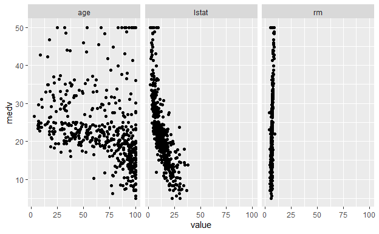

```r
Boston_df %>% select(medv,rm,age,lstat) %>%
  pivot_longer(cols=c("rm","age","lstat")) %>%
  ggplot(aes(x=value,y=medv)) + geom_point() +
  facet_wrap(~name)
```

This plot is potentially misleading due to the differences in scale between these three variables, let’s do one at a time:

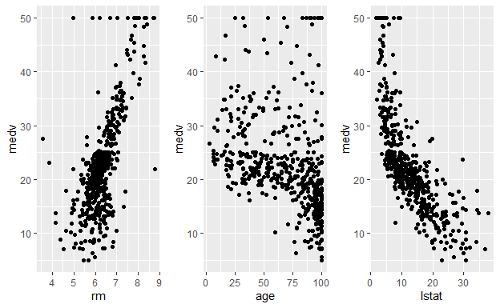

```r
p1 <- Boston_df %>% ggplot(aes(x=rm,y=medv)) + geom_point()
p2 <- Boston_df %>% ggplot(aes(x=age,y=medv)) + geom_point()
p3 <- Boston_df %>% ggplot(aes(x=lstat,y=medv)) + geom_point()
grid.arrange(p1,p2,p3,nrow=1)
```

Let’s compute the correlation of medv with each of rm, age, and lstat

```r
(with(Boston_df,cor(rm,medv)))
```

```
[1] 0.6953599
```

```r
(with(Boston_df,cor(age,medv)))
```

```
[1] -0.3769546
```

```r
(with(Boston_df,cor(lstat,medv)))
```

```
[1] -0.7376627
```

To try to predict medv using rm, age, and lstat with a linear model (*i.e.* mulitple linear regression) in R we simple use:

```r
Boston_lm <- lm(medv ~ rm + age + lstat,data=Boston_df)
```

Let’s look at the results:

```r
tidy(Boston_lm)
```

| term | estimate | std.error | statistic | p.value |
| --- | --- | --- | --- | --- |
| (Intercept) | -1.175311495 | 3.18192449 | -0.3693713 | 7.120068e-01 |
| rm | 5.019133481 | 0.45430637 | 11.0479047 | 1.505613e-25 |
| age | 0.009091327 | 0.01121503 | 0.8106381 | 4.179577e-01 |
| lstat | -0.668513052 | 0.05435747 | -12.2984583 | 1.437473e-30 |

**Note:** The estimate column gives us the estimated values for the coefficients. Also contained in this output is teh standard error for each estimate along with the corresponding observed t-statistic value and p-value. Even if we are not interested in inference, this information may still be useful in deciding which if any of the variables rm, age, or lstat is actually contributing to the response outcome. We will return to this discuss this in greater detail later.

```r
glance(Boston_lm)
```

| r.squared | adj.r.squared | sigma | statistic | p.value | df | logLik | AIC | BIC | deviance | df.residual |
| --- | --- | --- | --- | --- | --- | --- | --- | --- | --- | --- |
| 0.6390341 | 0.636877 | 5.542147 | 296.2377 | 1.202795e-110 | 4 | -1582.44 | 3174.88 | 3196.013 | 15419.13 | 502 |

**Note:** This resturns statistical information related to goodness of fit.

Any time we conduct a regression it is a good idea to plot the residuals versus the fitted values:

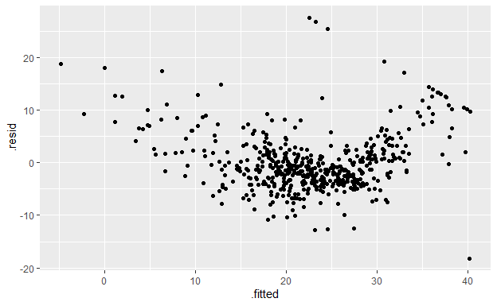

```r
augment(Boston_lm,data=Boston_df) %>% ggplot(aes(x=.fitted,y=.resid)) + geom_point()
```

**Question:** What do you observe about this plot?

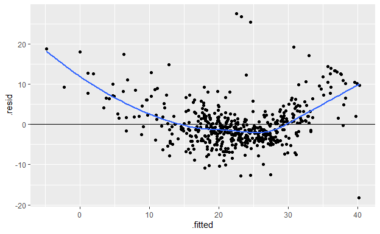

```r
augment(Boston_lm,data=Boston_df) %>%
  ggplot(aes(x=.fitted,y=.resid)) +
  geom_point() +
  geom_hline(yintercept = 0) +
  geom_smooth(se=FALSE)
```

**Observation:** This residual versus fitted plot suggests that the assumption of a linear relationship between medv and rm, age, lstat may be too restrictive.

R makes it easy to fit a response to all of the predictors in the data set:

```r
lm(medv~.,data=Boston_df) %>% tidy()
```

| term | estimate | std.error | statistic | p.value |
| --- | --- | --- | --- | --- |
| (Intercept) | 3.645949e+01 | 5.103458811 | 7.14407419 | 3.283438e-12 |
| crim | -1.080114e-01 | 0.032864994 | -3.28651687 | 1.086810e-03 |
| zn | 4.642046e-02 | 0.013727462 | 3.38157628 | 7.781097e-04 |
| indus | 2.055863e-02 | 0.061495689 | 0.33431004 | 7.382881e-01 |
| chas | 2.686734e+00 | 0.861579756 | 3.11838086 | 1.925030e-03 |
| nox | -1.776661e+01 | 3.819743707 | -4.65125741 | 4.245644e-06 |
| rm | 3.809865e+00 | 0.417925254 | 9.11614020 | 1.979441e-18 |
| age | 6.922246e-04 | 0.013209782 | 0.05240243 | 9.582293e-01 |
| dis | -1.475567e+00 | 0.199454735 | -7.39800360 | 6.013491e-13 |
| rad | 3.060495e-01 | 0.066346440 | 4.61289977 | 5.070529e-06 |

[output cut: 4 more lines]

We can also “update” a fit to modify what features (variables) to include:

```r
Boston_lm2 <- update(Boston_lm,~.-age)
```

```r
Boston_lm2 %>% tidy()
```

| term | estimate | std.error | statistic | p.value |
| --- | --- | --- | --- | --- |
| (Intercept) | -1.3582728 | 3.17282778 | -0.4280953 | 6.687649e-01 |
| rm | 5.0947880 | 0.44446550 | 11.4627299 | 3.472258e-27 |
| lstat | -0.6423583 | 0.04373146 | -14.6886992 | 6.669365e-41 |

Let’s examine the residual versus fitted plot:

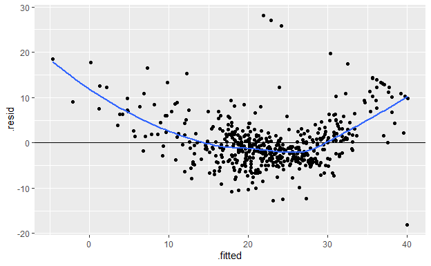

```r
augment(Boston_lm2,data=Boston_df) %>%
  ggplot(aes(x=.fitted,y=.resid)) +
  geom_point() +
  geom_hline(yintercept = 0) +
  geom_smooth(se=FALSE)
```

**Question:** There is not much of a difference between this and what we saw before, why?

# Multiple Regression Questions

When we perform multiple linear regression, we are interested in answering one or more of the following questions:

1. Is a least one of the predictors useful in predicting the response?
2. Do all the predictors help to explain the response, or is only a subset of the predictors useful?
3. How well does the model fit the data?
4. Given a set of predictor values, what response value should we predict, and how accurate is our prediction.

## Question 1)

To answer question 1) Is a least one of the predictors useful in predicting the response? We can use a permutation test for the F-statistic to test the null hypothesis

$H_{0}$: $m_{1} = m_{2} = \cdots = m_{p} = 0$

versus the alternatice hypothesis

$H_{A}$: At least one of the $m_{i}$ coefficients is non-zero.

```r
summary(Boston_lm)
```

```
Call:
lm(formula = medv ~ rm + age + lstat, data = Boston_df)

Residuals:
    Min      1Q  Median      3Q     Max
-18.210  -3.467  -1.053   1.957  27.500

Coefficients:
             Estimate Std. Error t value Pr(>|t|)
(Intercept) -1.175311   3.181924  -0.369    0.712
rm           5.019133   0.454306  11.048   <2e-16 ***
age          0.009091   0.011215   0.811    0.418
lstat       -0.668513   0.054357 -12.298   <2e-16 ***
---
Signif. codes:  0 ‘***’ 0.001 ‘**’ 0.01 ‘*’ 0.05 ‘.’ 0.1 ‘ ’ 1

Residual standard error: 5.542 on 502 degrees of freedom
Multiple R-squared:  0.639, Adjusted R-squared:  0.6369
F-statistic: 296.2 on 3 and 502 DF,  p-value: < 2.2e-16
```

Notice that we can obtain the F-statistic value from the output of lm() and do not need to use a formula for it:

```r
(observed_F <- summary(Boston_lm)$fstatistic[1])
```

```
   value
296.2377
```

Let’s conduct our permutation test:

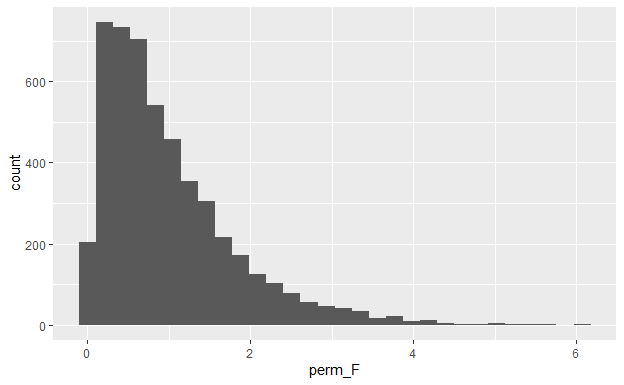

```r
N <- 5000
perm_F <- numeric(N)
for (i in 1:N){
  temp_lm <- lm(sample(medv)~rm + age + lstat,data=Boston_df)
  perm_F[i] <- summary(temp_lm)$fstatistic[1]
}
ggplot(data=NULL,mapping=aes(x=perm_F)) +
  geom_histogram()
```

Notice that most of the resampled F-statistic values fall around 1 whereas the observed F-statistic value is almost 300. Just intuitively we can see that our p-value will be extremely small. This the null hypothesis should be rejected.

Observe that the output of the following command gives the p-value computed using analytic formulas:

```r
summary(Boston_lm)
```

```
Call:
lm(formula = medv ~ rm + age + lstat, data = Boston_df)

Residuals:
    Min      1Q  Median      3Q     Max
-18.210  -3.467  -1.053   1.957  27.500

Coefficients:
             Estimate Std. Error t value Pr(>|t|)
(Intercept) -1.175311   3.181924  -0.369    0.712
rm           5.019133   0.454306  11.048   <2e-16 ***
age          0.009091   0.011215   0.811    0.418
lstat       -0.668513   0.054357 -12.298   <2e-16 ***
---
Signif. codes:  0 ‘***’ 0.001 ‘**’ 0.01 ‘*’ 0.05 ‘.’ 0.1 ‘ ’ 1

Residual standard error: 5.542 on 502 degrees of freedom
Multiple R-squared:  0.639, Adjusted R-squared:  0.6369
F-statistic: 296.2 on 3 and 502 DF,  p-value: < 2.2e-16
```

The p-value for the F-statistic here is very small.

### Another Example

Let’s examine a situation where we know that there is a linear relationship between a set of predictors and a response.

We simulate some data:

```r
x1 <- rnorm(45,12,3.2)
x2 <- rnorm(45,3,0.2)
x3 <- rnorm(45,27,17)
y <- 2*(x1)^2 + 3*x2*x3 - 35 + rnorm(45,sd=13)
sim_df <- data.frame(x1=x1,x2=x2,x3=x3,y=y)
```

Now let’s obtain a linear regression fit and examine the results:

```r
lm_sim_df <- lm(y~.,data=sim_df)
```

```r
tidy(lm_sim_df)
```

| term | estimate | std.error | statistic | p.value |
| --- | --- | --- | --- | --- |
| (Intercept) | -581.312334 | 74.2150512 | -7.832809 | 1.128579e-09 |
| x1 | 47.144520 | 1.8107253 | 26.036262 | 4.032457e-27 |
| x2 | 90.643991 | 21.3304167 | 4.249518 | 1.203411e-04 |
| x3 | 9.155955 | 0.2390805 | 38.296541 | 1.013120e-33 |

```r
glance(lm_sim_df)
```

| r.squared | adj.r.squared | sigma | statistic | p.value | df | logLik | AIC | BIC | deviance | df.residual |
| --- | --- | --- | --- | --- | --- | --- | --- | --- | --- | --- |
| 0.979402 | 0.9778948 | 29.49376 | 649.828 | 1.397198e-34 | 4 | -214.0457 | 438.0915 | 447.1248 | 35665.17 | 41 |

Let’s plot the residual versus fitted:

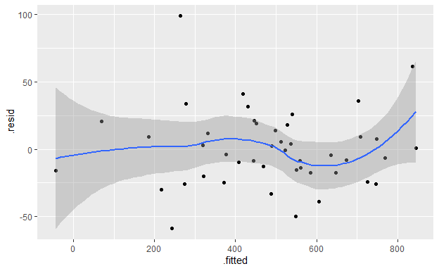

```r
augment(lm_sim_df,data=sim_df) %>%
  ggplot(aes(x=.fitted,y=.resid)) +
  geom_point() + geom_smooth()
```

Let’s repeat our permutation test for the F-statistic to test the null hypothesis:

$H_{0}$: $m_{1}=m_{2}=m_{3} = 0$

versus the alternative

$H_{A}$: at least one of $m_{1},m_{2},m_{3}$ is not zero.

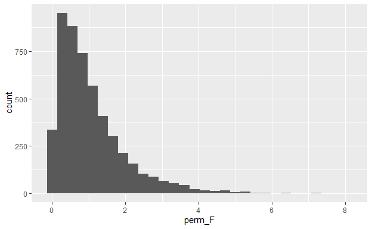

```r
N <- 5000
perm_F <- numeric(N)
for (i in 1:N){
  temp_lm <- lm(sample(y)~.,data=sim_df)
  perm_F[i] <- summary(temp_lm)$fstatistic[1]
}
ggplot(data=NULL,mapping=aes(x=perm_F)) +
  geom_histogram()
```

Here is the observed F-statistic value:

```r
(observed_F <- summary(lm_sim_df)$fstatistic[1])
```

```
  value
649.828
```

**Question:** Should we reject or fail to reject the null hypothesis?

**Exercise:** Try this again but remove the dependence of the response $y$ in the simluted data on the preditors.

**Exercise:** What happens if we have the response $y$ in the simluted data depend one or more of the preditors but in a non-linear fashion?

## Question 2)

Suppose that we use the F-statistic to conclude that there is sufficient evidence to reject the null hypothesis that all of the “slope” parameters in a linear regression model are zero. The next question is, exactly which of the p predictor variables are associated with the response?

This is referred to as **variable selection.** There are a few different ways to handle this. One way is by brut force where we try out all possible (linear) model combinations. There are three common approaches, the forward selection approach (start with no variables and add one at a time), the backward selection approach (start with all variables and remove one at a time), or a sort of combination of the forward and backward approach.

One question we must address is, what metric should we use in order to assess the results of comparing each of the different variable combinations. There are several options here, Mallow’s $C_{p}$, AIC, BIC, and adjusted $R^2$. See Chapter 3 Section 3.2.2 of [An Introduction to Statistical Learning](http://faculty.marshall.usc.edu/gareth-james/ISL/) for more details.

Rather than go through all of the details here, we will use the variable selection functions from the [olsrr package](https://cran.r-project.org/web/packages/olsrr/vignettes/intro.html).

Let’s start with an example based on simulated data:

```r
x1 <- rnorm(45,12,3.2)
x2 <- rnorm(45,3,0.2)
x3 <- rnorm(45,27,17)
y <-  0.1*x1 + 3*x3 - 35 + rnorm(45,sd=13)
sim_df <- data.frame(x1=x1,x2=x2,x3=x3,y=y)
```

Notice that we removed any dependence on x2. If we fit the model, here is the result:

```r
sim_lm_fit <- lm(y~.,data=sim_df)
summary(sim_lm_fit)
```

```
Call:
lm(formula = y ~ ., data = sim_df)

Residuals:
    Min      1Q  Median      3Q     Max
-17.431  -8.939  -2.853   5.559  27.399

Coefficients:
            Estimate Std. Error t value Pr(>|t|)
(Intercept) -31.3550    31.3648  -1.000   0.3233
x1            1.1206     0.6169   1.816   0.0766 .
x2           -6.5001    10.1648  -0.639   0.5261
x3            3.1349     0.1088  28.816   <2e-16 ***
---
Signif. codes:  0 ‘***’ 0.001 ‘**’ 0.01 ‘*’ 0.05 ‘.’ 0.1 ‘ ’ 1

Residual standard error: 12.13 on 41 degrees of freedom
Multiple R-squared:  0.9577,    Adjusted R-squared:  0.9546
F-statistic: 309.6 on 3 and 41 DF,  p-value: < 2.2e-16
```

Since there are only three predictors, there are a total of eight possible variable combinations for a linear model so in this case it is not too “expensive” to fit all possible models and compare:

```r
(var_select_results<-ols_step_all_possible(sim_lm_fit))
```

| Index | N | Predictors | R-Square | Adj. R-Square | Mallow's Cp |
| --- | --- | --- | --- | --- | --- |
| 1 | 1 | x3 | 0.95350723 | 0.952426008 | 4.092193 |
| 2 | 1 | x2 | 0.08660593 | 0.065364208 | 844.878509 |
| 3 | 1 | x1 | 0.03222648 | 0.009720122 | 897.619801 |
| 4 | 2 | x1 x3 | 0.95730490 | 0.955271802 | 2.408928 |
| 5 | 2 | x2 x3 | 0.95432473 | 0.952149719 | 5.299322 |
| 6 | 2 | x1 x2 | 0.10156363 | 0.058780948 | 832.371400 |
| 7 | 3 | x1 x2 x3 | 0.95772653 | 0.954633351 | 4.000000 |

Let’s look at what all is contained in the output for this function.

```r
names(var_select_results)
```

```
 [1] "mindex"     "n"          "predictors" "rsquare"
 [5] "adjr"       "predrsq"    "cp"         "aic"
 [9] "sbic"       "sbc"        "msep"       "fpe"
[13] "apc"        "hsp"
```

We see that the AIC values are also computed:

```r
var_select_results$aic
```

```
[1] 358.3744 492.3786 494.9810 356.5398 359.5761 493.6356
[7] 358.0932
```

The model that minimizes AIC is regarded as best and we see that this is the model that includes on x1 and x3.

**Question** Why do we expect this result?

The plot function will produce a plot:

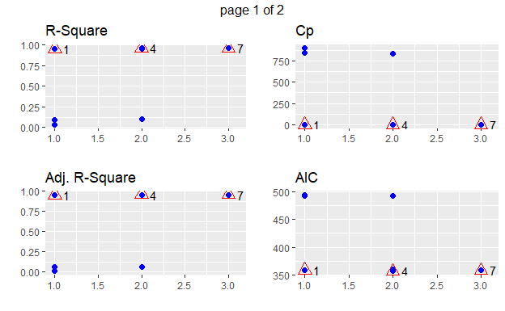

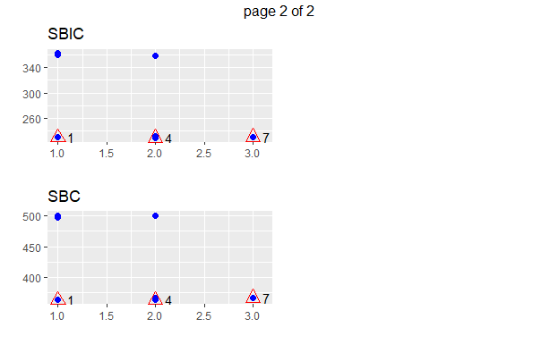

```r
plot(var_select_results)
```

Another similar function is

```r
(var_subset_result <- ols_step_best_subset(sim_lm_fit))
```

```
Best Subsets Regression
-----------------------
Model Index    Predictors
-----------------------
     1         x3
     2         x1 x3
     3         x1 x2 x3
-----------------------

                                                    Subsets Regression Summary
-----------------------------------------------------------------------------------------------------------------------------------
                       Adj.        Pred
Model    R-Square    R-Square    R-Square     C(p)       AIC         SBIC        SBC         MSEP        FPE        HSP       APC
-----------------------------------------------------------------------------------------------------------------------------------
  1        0.9535      0.9524       0.949    4.0922    358.3744    230.6618    363.7944    161.3599    161.0336    3.6710    0.0508
  2        0.9573      0.9553       0.952    2.4089    356.5398    229.3407    363.7665    155.4078    154.6221    3.5356    0.0488
  3        0.9577      0.9546        0.95    4.0000    358.0932    231.1502    367.1266    161.5668    160.0965    3.6757    0.0505
-----------------------------------------------------------------------------------------------------------------------------------
AIC: Akaike Information Criteria
 SBIC: Sawa's Bayesian Information Criteria
 SBC: Schwarz Bayesian Criteria
 MSEP: Estimated error of prediction, assuming multivariate normality
 FPE: Final Prediction Error
 HSP: Hocking's Sp
 APC: Amemiya Prediction Criteria
```

The plot function works on this as well:

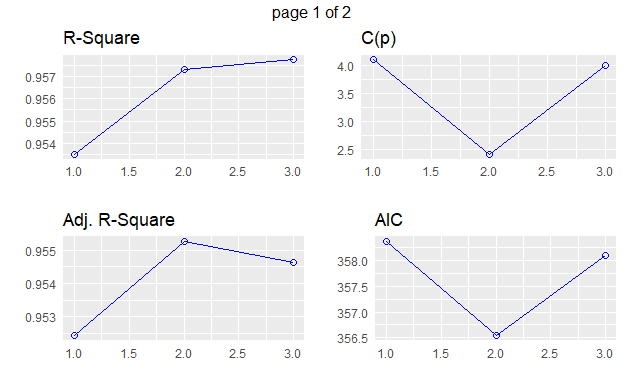

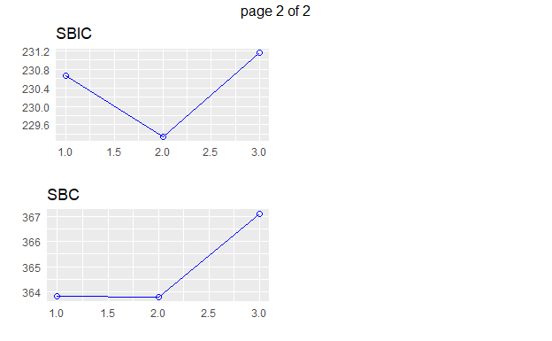

```r
plot(var_subset_result)
```

There are also functions that implement forward and backward selection, for example:

```r
var_forward_select <- ols_step_forward_aic(sim_lm_fit)
```

```
Forward Selection Method
------------------------

Candidate Terms:

1 . x1
2 . x2
3 . x3


Variables Entered:

✔ x3
✔ x1

No more variables to be added.
```

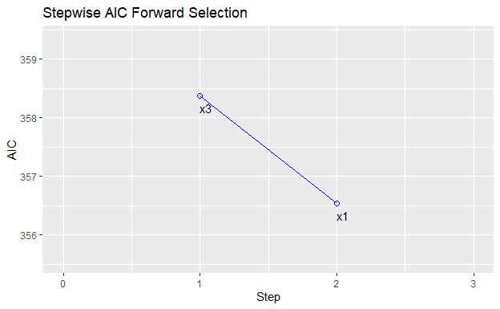

```r
plot(var_forward_select)
```

### Example with Boston Housing Data

```r
Boston_lm_all <- lm(medv ~ . , data=Boston_df)
(Boston_selection <- ols_step_both_aic(Boston_lm_all))
```

```
Stepwise Selection Method
-------------------------

Candidate Terms:

1 . crim
2 . zn
3 . indus
4 . chas
5 . nox
6 . rm
7 . age
8 . dis
9 . rad
10 . tax
11 . ptratio
12 . black
13 . lstat


Variables Entered/Removed:

✔ lstat
✔ rm
✔ ptratio
✔ dis
✔ nox
✔ chas
✔ black
✔ zn
✔ crim
✔ rad
✔ tax

No more variables to be added or removed.

                                  Stepwise Summary
----------------------------------------------------------------------------------
Variable     Method       AIC          RSS        Sum Sq       R-Sq      Adj. R-Sq
----------------------------------------------------------------------------------
lstat       addition    3288.975    19472.381    23243.914    0.54415      0.54324
rm          addition    3173.542    15439.309    27276.986    0.63856      0.63712
ptratio     addition    3116.097    13727.985    28988.310    0.67862      0.67670
dis         addition    3099.359    13228.908    29487.388    0.69031      0.68784
nox         addition    3071.439    12469.344    30246.951    0.70809      0.70517
chas        addition    3059.939    12141.073    30575.223    0.71577      0.71236
black       addition    3050.438    11868.236    30848.060    0.72216      0.71826
zn          addition    3044.275    11678.299    31037.996    0.72661      0.72221
crim        addition    3042.155    11583.588    31132.708    0.72883      0.72390
rad         addition    3034.069    11354.983    31361.312    0.73418      0.72881
tax         addition    3023.726    11081.364    31634.931    0.74058      0.73481
----------------------------------------------------------------------------------
```

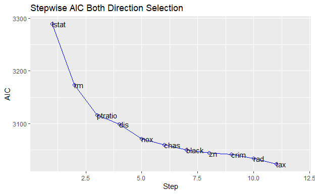

```r
plot(Boston_selection)
```

```r
Boston_selection$predictors
```

```
 [1] "lstat"   "rm"      "ptratio" "dis"     "nox"
 [6] "chas"    "black"   "zn"      "crim"    "rad"
[11] "tax"
```

```r
names(Boston_df)
```

```
 [1] "crim"    "zn"      "indus"   "chas"    "nox"
 [6] "rm"      "age"     "dis"     "rad"     "tax"
[11] "ptratio" "black"   "lstat"   "medv"
```

**Note:** We note that variable selection can help to a certain extent in avoiding over-fitting but it is not the only point to consider regarding over-fitting because it still does not provide insight into the test MSE. Cross-validation (CV), we will discuss later, is another technique used to examine over-fitting related issues. CV is a ressampling method that provides a means to approximate test error.

## Question 3)

How well does the model fit the data?

The two most common numerical measures for model fit are residual standard error (RSE), which is an estimate of the standard deviation of $\epsilon$; and $R^2$, which describes the proportion of variation that is explained by the model.

**Note:** Typical approaches to estimating the standard deviation of $\epsilon$ assume that this is a constant (independent of $x$). This assumption is known as **homoscedasticity**. Also, the RSE provides an absolute measure of *lack of fit*. A large RSE suggests a poor fit. $R^2$ is always between 0 and 1 and thus represents a proportion. An $R^2$ value close to 1 suggests that the model explains a large portion of the variance in the response variable.

The output from the glance() function contains the values of RSE and $R^2$. For example,

```r
glance(sim_lm_fit)
```

| r.squared | adj.r.squared | sigma | statistic | p.value | df | logLik | AIC | BIC | deviance | df.residual |
| --- | --- | --- | --- | --- | --- | --- | --- | --- | --- | --- |
| 0.9577265 | 0.9546334 | 12.12548 | 309.6252 | 3.480222e-28 | 4 | -174.0466 | 358.0932 | 367.1266 | 6028.122 | 41 |

the frst column is $R^2$ and the column sigma is the RSE. Compare this with the output from

```r
summary(sim_lm_fit)
```

```
Call:
lm(formula = y ~ ., data = sim_df)

Residuals:
    Min      1Q  Median      3Q     Max
-17.431  -8.939  -2.853   5.559  27.399

Coefficients:
            Estimate Std. Error t value Pr(>|t|)
(Intercept) -31.3550    31.3648  -1.000   0.3233
x1            1.1206     0.6169   1.816   0.0766 .
x2           -6.5001    10.1648  -0.639   0.5261
x3            3.1349     0.1088  28.816   <2e-16 ***
---
Signif. codes:  0 ‘***’ 0.001 ‘**’ 0.01 ‘*’ 0.05 ‘.’ 0.1 ‘ ’ 1

Residual standard error: 12.13 on 41 degrees of freedom
Multiple R-squared:  0.9577,    Adjusted R-squared:  0.9546
F-statistic: 309.6 on 3 and 41 DF,  p-value: < 2.2e-16
```

**Note:** The residual versus fitted values plot is a good way to check for (the violation of) homoscedasticity. Consider the following simulated example:

```r
x <- rnorm(75,mean=2,sd=1.7)
heterogeneous_sd <- function(x) sapply(x,function(x) rnorm(1,mean=0,sd=5*abs(x)))
y <- 2*x + heterogeneous_sd(x)
df <- data.frame(x=x,y=y)
```

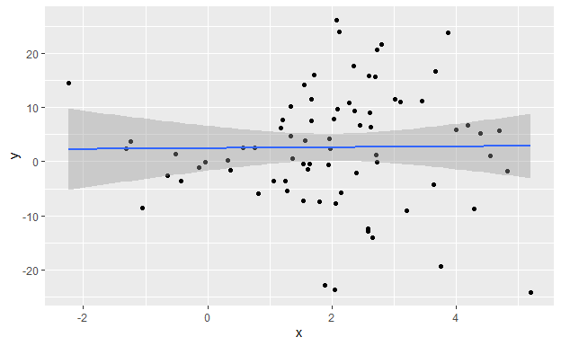

```r
df %>% ggplot(aes(x=x,y=y)) + geom_point() +
  geom_smooth(method = "lm")
```

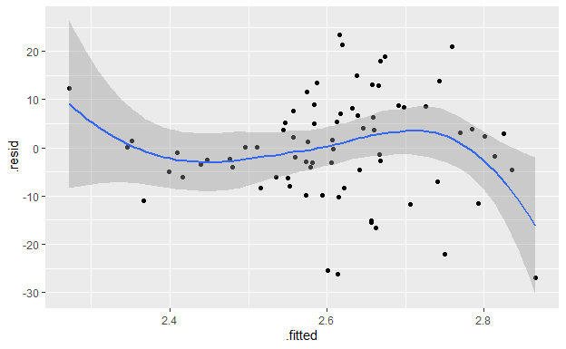

```r
lm_fit_heteroscedasticity <- lm(y~x,data=df)
augment(lm_fit_heteroscedasticity,data=df) %>%
  ggplot(aes(x=.fitted,y=.resid)) + geom_point() +
  geom_smooth()
```

Here we can “observe” the violation of homoscedasticity.

## Question 4)

Suppose we fit a linear model using some predictor/response pair of sampled data. There will be three main sources of error:

1. Error due to bias because of the likely simplifying assumption of linearity.
2. The irreducible error that comes from estimating population parameters. This error is measured by confidence intervals.
3. The irreducible error due to $\epsilon$. Error arising from $\epsilon$ in making predictions is measured by **prediction intervals**. These will always be wider than confidence intervals because they incorporate both the error in the estimate for $f(X)$ and the uncertainty as to how much an individual point will differ from the population regression plane (the irreducible error).

The predict() function can be used to return the prediction intervals for new values. Let’s look at an example.

Let’s go back to the simulated data

```r
x1 <- rnorm(45,12,3.2)
x2 <- rnorm(45,3,0.2)
x3 <- rnorm(45,27,17)
y <-  0.1*x1 + 15*x2 + 3*x3 - 35 + rnorm(45,sd=13)
sim_df <- data.frame(x1=x1,x2=x2,x3=x3,y=y)
```

We will fit a multiple linear regression model:

```r
sim_df_lm <- lm(y~.,data=sim_df)
```

Let’s produce some more data:

```r
x1_new <- rnorm(10,12,3.2)
x2_new <- rnorm(10,3,0.2)
x3_new <- rnorm(10,27,17)
predict(sim_df_lm,newdata = data.frame(x1=x1_new,x2=x2_new,x3=x3_new),interval = "prediction")
```

```
         fit       lwr       upr
1  109.77199  79.17262 140.37135
2  146.81596 115.46288 178.16903
3   73.20317  42.07101 104.33533
4   60.27790  29.25913  91.29668
5  177.09819 145.76796 208.42841
6  107.18665  75.79528 138.57802
7   97.50201  66.82354 128.18049
8   69.56920  38.76498 100.37342
9  119.50914  87.85717 151.16111
10 138.73557 107.61750 169.85365
```

Compare this with

```r
predict(sim_df_lm,newdata = data.frame(x1=x1_new,x2=x2_new,x3=x3_new),interval = "confidence")
```

```
         fit       lwr       upr
1  109.77199 105.02629 114.51769
2  146.81596 138.49636 155.13556
3   73.20317  65.75925  80.64708
4   60.27790  53.32342  67.23238
5  177.09819 168.86511 185.33126
6  107.18665  98.72387 115.64943
7   97.50201  92.27043 102.73360
8   69.56920  63.64464  75.49377
9  119.50914 110.12577 128.89251
10 138.73557 131.35076 146.12039
```

It is also possible to use bootstrap to approximate prediction intervals but we will not need this very often so we will postpone any discussion of this.

There are three more topics that we will address regarding regression modeling before then moving on the look at some methods for classification:

1. Estimating test error for regression models. This involves covering the idea of cross-validation.
2. Dealing with nonlinearity.
3. Using regression for binary classification.

These will be addressed in future notebooks.